# Exploring the BRFSS data

## Setup

### Load packages

```r
library(ggplot2)
library(dplyr)
library(statsr)
```

### Load data

```r
load("brfss2013.RData")
```

## Part 1: Data

Because there is no random assignment, this dataset cannot be used to infer causality. Even if we find strong associations among variables, confounders may mask the true causal factors involved. However, this rich dataset can serve as a tool for exploratory data analysis and to detect correlational relationships between or among variables. * * *

## Part 2: Research questions

**Research quesion 1: Which U.S. State had most people overweight or obese?**

**Research quesion 2: In California, how does sleep time vary per month? And in which month do people get the most sleep?**

**Research quesion 3: In the USA, is there some association between number of people in a household and self-reported depression over the past 30 days?**

## Part 3: Exploratory data analysis

**Research quesion 1: Which U.S. State had most people overweight or obese?**

```r
# let's create a smaller dataframe with only the BMI and state variables.
state_weight_df <- subset(brfss2013, select = c(X_rfbmi5, X_state))

# create a dataframe with only complete cases
complete_state_weight_df <- na.omit(state_weight_df)

# Since we do not assume the number sampled is the same for each "state", we
# will calculate the percentage of obesity per state and then sort in
# descending order.

complete_state_weight_df %>%
  group_by(X_state) %>%
  summarise(obesity_rate = sum( X_rfbmi5 == "Yes"  ) / n()) %>%
  arrange(desc(obesity_rate))
```

```
## Source: local data frame [53 x 2]
##
##          X_state obesity_rate
##           <fctr>        <dbl>
## 1    Mississippi    0.7000853
## 2      Louisiana    0.6971520
## 3  West Virginia    0.6939319
## 4       Kentucky    0.6919682
## 5        Alabama    0.6907431
## 6   North Dakota    0.6906785
## 7       Arkansas    0.6884332
## 8      Wisconsin    0.6837427
## 9        Indiana    0.6810645
## 10  South Dakota    0.6806002
## ..           ...          ...
```

```r
# Mississippi seems to be the state with the highest rate of overweight
# or obese residents.
# Note that because I used complete cases, the non-response could potentially
# bias the estimates.
```

**Research quesion 2: In California, how does sleep time vary per month? And in which month do people get the most sleep?**

```r
# Create smaller dataframe with only California
brfss2013_CA <- subset(brfss2013, X_state == "California")

# Create smaller dataframe with variables of interest: month and sleep time
brfss2013_CA_smalldf <- subset(brfss2013_CA, select=c(fmonth, sleptim1))

# Omit NA's to create a dataframe with complete cases
complete_brfss2013_CA_smalldf <- na.omit(brfss2013_CA_smalldf)

# Calculate mean sleep time per month in descending order
complete_brfss2013_CA_smalldf %>%
  group_by(fmonth) %>%
  summarise(mean_sleep = mean(sleptim1)) %>%
  arrange(desc(mean_sleep))
```

```
## Source: local data frame [12 x 2]
##
##       fmonth mean_sleep
##       <fctr>      <dbl>
## 1     August   7.500000
## 2   December   7.375000
## 3   November   7.238806
## 4   February   7.156250
## 5      April   7.129496
## 6    October   7.101273
## 7  September   7.093023
## 8    January   7.051558
## 9       July   7.028393
## 10       May   6.988012
## 11      June   6.946429
## 12     March   6.821429
```

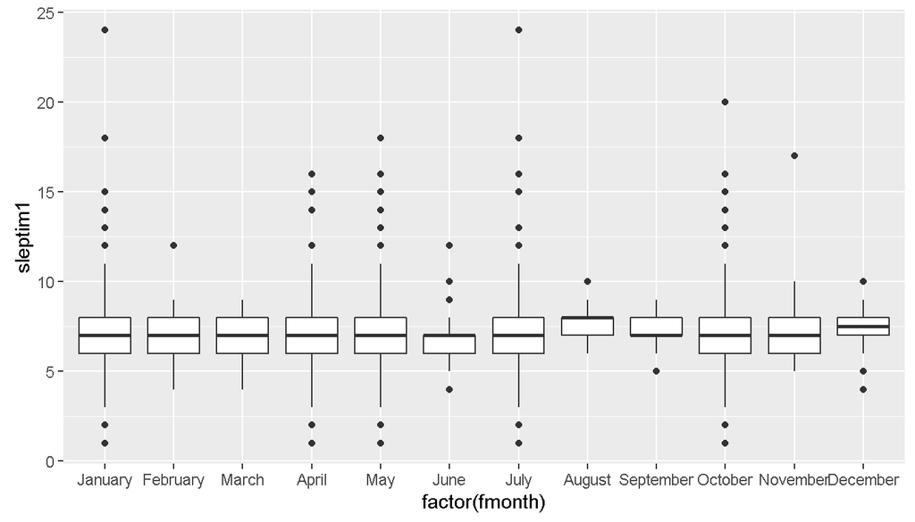

```r
# The month with most sleep time is August. Maybe this coincides with
# summer vacation? The monthwith second largest sleep time is December, and
# this coincides with winter vacation and the holidays.

# We can visualize the distributions of sleep time across months using
# side-by-side box plots:

ggplot(complete_brfss2013_CA_smalldf, aes(x = factor(fmonth), y = sleptim1)) +
  geom_boxplot()
```

```r
# Finally, I must reiterate that though it was necessary to calculate values
# only for complete cases, this coud bias the estimates if the missingness
# was informative.
```

**Research quesion 3: In the USA, is there some association between number of people in a household and self-reported depression over the past 30 days?**

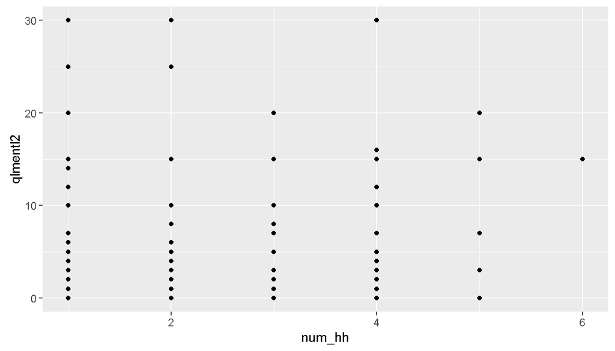

```r
# First, I create a smaller dataframe with variables of interest
small_brfss2013_df <- subset(brfss2013, select=c(numadult, children, qlmentl2))

# Second, I create a dataframe with only complete cases
complete_small_brfss2013_df <- na.omit(small_brfss2013_df)

# Third, I add the number of adults and children to create a new variable
# representing the number of people in the household
complete_small_brfss2013_df$num_hh <- as.numeric(complete_small_brfss2013_df$numadult) + complete_small_brfss2013_df$children

# Finally, I graph the results on a scatterplot
ggplot(data = complete_small_brfss2013_df, aes(x = num_hh, y = qlmentl2)) +
  geom_point()
```

```r
# There does NOT seem to be any relationship between number of people in the
# household and self-reported depression over the past 30 days.
#
# As I mentioned
# in previous questions, if missingness if correlated with numbers of people
# in the household or depression, then the estimates I just calculated may be
# biased.
```